# env.Ztest()

where $f_{ij}$ is the computed relative frequency for amino acid $i$ at position $j$, and $n$ is is the total number of environmental sequences analyzed.

```r
kable(round(results[[1]], 1))
```

|  | -5 | -4 | -3 | -2 | -1 | 0 | 1 | 2 | 3 | 4 | 5 |
| --- | --- | --- | --- | --- | --- | --- | --- | --- | --- | --- | --- |
| A | -0.4 | -1.4 | 0.0 | 0.3 | -0.6 | 0 | -1.5 | 0.0 | -0.5 | -2.1 | -1.4 |
| C | -0.6 | 1.5 | 0.0 | -1.0 | -0.6 | 0 | -1.5 | 0.0 | -1.0 | 0.0 | 0.0 |
| D | 0.0 | -0.6 | -1.0 | -0.6 | -1.5 | 0 | 1.2 | 0.6 | 0.0 | 1.8 | -1.0 |
| E | 0.0 | -1.8 | 1.2 | -2.9 | -0.4 | 0 | 0.0 | -0.7 | 2.0 | -0.6 | 0.0 |
| F | 0.0 | 1.0 | -1.0 | -1.0 | -1.8 | 0 | 0.0 | 0.0 | 0.0 | 1.0 | 1.8 |
| G | 0.4 | 0.5 | -1.2 | 1.2 | -0.4 | 0 | -0.3 | 0.7 | -0.5 | -1.5 | -0.5 |
| H | 0.0 | 1.0 | -1.0 | 1.0 | -1.0 | 0 | 1.0 | 0.0 | 0.0 | 0.0 | -1.5 |
| I | 1.5 | 0.4 | -0.5 | 0.0 | 0.0 | 0 | 1.8 | -0.5 | 0.0 | 1.8 | -1.8 |
| K | 1.8 | 0.9 | -1.7 | 0.6 | 0.6 | 0 | 0.0 | 0.4 | 0.7 | 0.9 | -0.4 |
| L | 0.7 | 0.0 | -0.9 | 3.2 | 0.6 | 0 | -0.5 | -1.0 | 1.5 | -1.2 | 1.7 |
| M | 0.0 | -1.0 | -1.0 | 0.0 | 0.0 | 0 | 1.5 | 0.0 | -1.0 | -1.0 | 0.0 |
| N | 1.5 | 1.0 | 1.0 | -1.8 | -0.6 | 0 | -0.5 | 0.0 | -1.5 | 0.6 | 1.5 |
| P | -0.4 | 0.5 | 0.5 | -0.6 | -0.4 | 0 | 2.0 | -0.6 | 1.4 | 1.0 | -0.4 |
| Q | 0.0 | 1.5 | 1.7 | -1.7 | 0.0 | 0 | 0.5 | 1.2 | 1.0 | 0.0 | 0.0 |
| R | -0.6 | 1.7 | 1.8 | 0.6 | 2.1 | 0 | -0.6 | 0.6 | -0.9 | 0.0 | 1.8 |
| S | -1.0 | -1.1 | -0.4 | 1.5 | 0.0 | 0 | -1.1 | -1.2 | -0.6 | -0.3 | 0.0 |
| T | -1.4 | -0.7 | 0.6 | 0.5 | 1.8 | 0 | -1.0 | 1.0 | 0.0 | -0.5 | -0.4 |
| V | -0.6 | -0.5 | 0.0 | -1.7 | 0.6 | 0 | -0.9 | -0.9 | -2.1 | -1.5 | 1.4 |
| W | 1.0 | 0.0 | 0.0 | 1.0 | 0.0 | 0 | 0.0 | 1.0 | -1.5 | 0.6 | 0.0 |
| Y | 0.0 | -1.0 | 0.0 | 1.0 | 0.6 | 0 | -0.6 | 0.0 | 0.5 | 0.9 | -1.5 |
| X | 0.0 | 0.0 | 0.0 | 0.0 | 0.0 | 0 | 0.0 | 0.0 | 0.0 | 0.0 | 0.0 |

A standard score, $Z_{ij}$, that is much greater than zero or much less than zero indicates that amino acid $i$ is overrepresented or underrepresented at position $j$, respectively, in an environment of the positive sequences with respect to an environment of the control ones. To this respect, the second element of the list ‘results’ is a dataframe with information regarding those amino acids overrepresented in the positive environments (Z values much higher than 0):

```r
kable(results[[2]])
```

|  | aa | at | Z | pValue |
| --- | --- | --- | --- | --- |
| 5 | L | -2 | 3.162278 | 0.0007827 |
| 6 | R | -1 | 2.108185 | 0.0175075 |
| 9 | P | 1 | 2.028602 | 0.0212494 |
| 10 | E | 3 | 2.028602 | 0.0212494 |
| 4 | R | -3 | 1.804807 | 0.0355524 |
| 1 | K | -5 | 1.800901 | 0.0358593 |
| 7 | T | -1 | 1.800901 | 0.0358593 |
| 8 | I | 1 | 1.800901 | 0.0358593 |
| 11 | D | 4 | 1.800901 | 0.0358593 |
| 12 | I | 4 | 1.800901 | 0.0358593 |
| 13 | F | 5 | 1.800901 | 0.0358593 |
| 15 | R | 5 | 1.800901 | 0.0358593 |
| 2 | R | -4 | 1.729351 | 0.0418732 |
| 3 | Q | -3 | 1.729351 | 0.0418732 |
| 14 | L | 5 | 1.650696 | 0.0494004 |

The third element of the list is also a dataframe, but in this case with information regarding amino acid underrepresented in the positive environments (Z values much lower thant 0):

```r
kable(results[[3]])
```

|  | aa | at | Z | pValue |
| --- | --- | --- | --- | --- |
| 3 | E | -2 | -2.912876 | 0.0017906 |
| 8 | V | 3 | -2.108185 | 0.0175075 |
| 9 | A | 4 | -2.108185 | 0.0175075 |
| 1 | E | -4 | -1.800901 | 0.0358593 |
| 4 | N | -2 | -1.800901 | 0.0358593 |
| 7 | F | -1 | -1.800901 | 0.0358593 |
| 10 | I | 5 | -1.800901 | 0.0358593 |
| 2 | K | -3 | -1.729351 | 0.0418732 |
| 5 | Q | -2 | -1.729351 | 0.0418732 |
| 6 | V | -2 | -1.729351 | 0.0418732 |

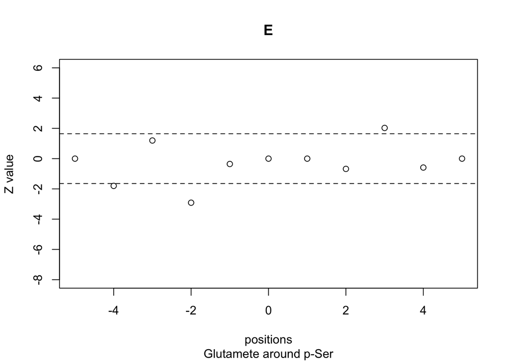

```r
env.plot(Z = results[[1]],
         aa = 'E',
         pValue = 0.05,
         title = "Glutamete around p-Ser")
```

while leucine is clearly enriched at that position:

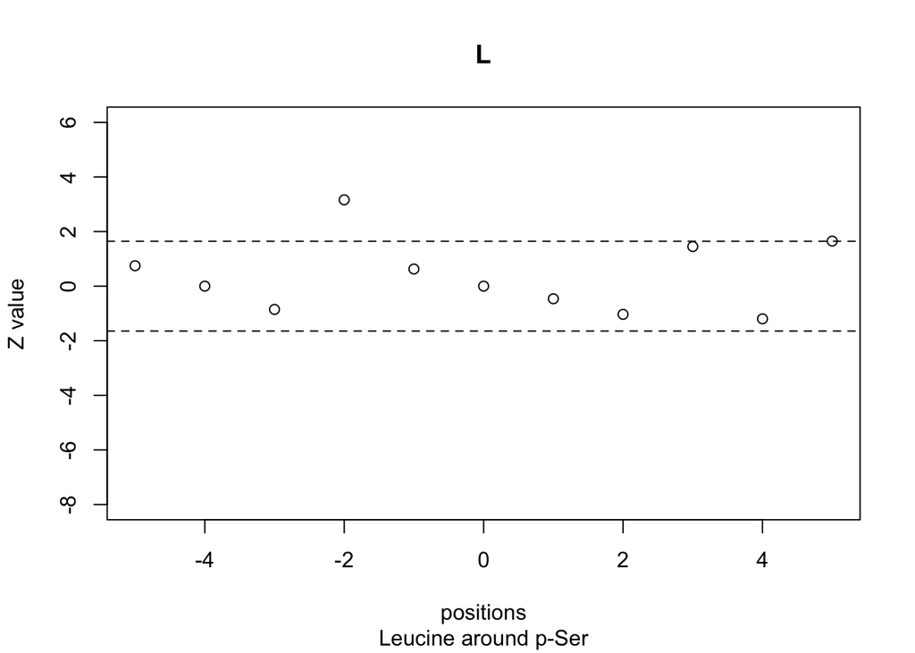

```r
env.plot(Z = results[[1]],
         aa = 'L',
         pValue = 0.05,
         title = "Leucine around p-Ser")
```